# R for Biologists: a powerful statistical tool in research

### Normal distribution

Biological variables are likely to be clustered around a central value (=mean).

The standard normal distribution curve is a curve that is shaped like a bell where the data is symmetrically distributed around the central value.

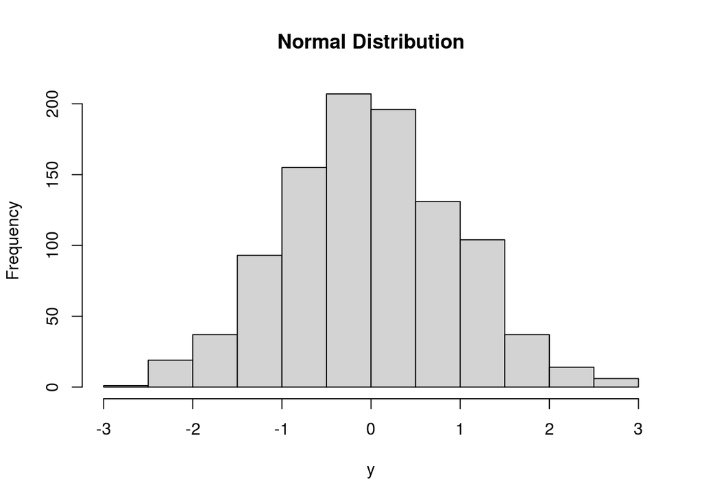

```r
## rnorm()
# Generate random numbers whose distribution is normal. It takes the sample size as input and generates that many random numbers.

y <- rnorm(1000)   # Create a sample of 1000 numbers which are normally distributed.
hist(y, main = "Normal Distribution") # Plot the histogram for this sample.
```

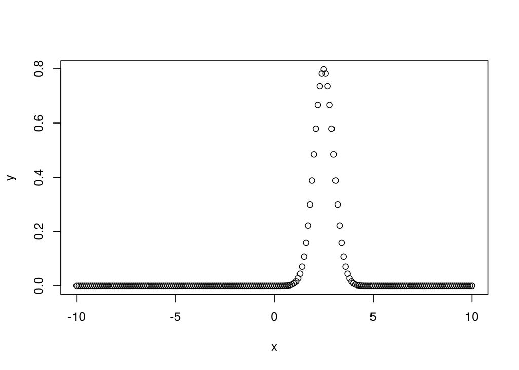

```r
##dnorm()
#This function gives height of the probability distribution at each point for a given mean and standard deviation.

x <- seq(-10, 10, by = .1) # Create a sequence of numbers between -10 and 10 incrementing by 0.1.

y <- dnorm(x, mean = 2.5, sd = 0.5) # Choose the mean as 2.5 and standard deviation as 0.5.

plot(x,y) # The bell-shape plot
```

### Skewed distribution

It is a distribution with an asymmetry of the observations about its mean. We count negatively skewed distribution (longer left tail) and positively skewed distribution (longer right tail).

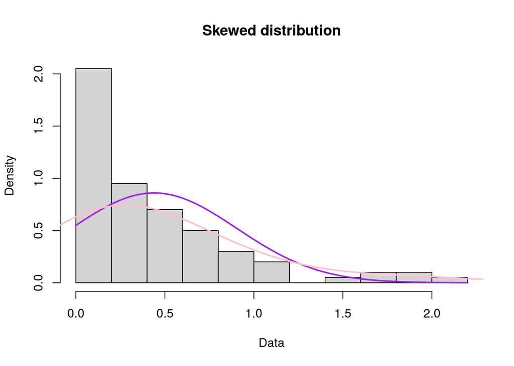

```r
#Create a nonnormal distribution
n=100                   #number of data point
right <-rexp(n,rate=2)    #exponential distribution (gamma 2

m <-mean(right )    # compute mean
 std<-sd(right )          # and std

title<-("Skewed distribution")

hist(right, xlab="Data", freq= FALSE, main=title)
curve(dnorm(x, mean=m, sd=std), col="purple", lwd=2, add=TRUE) # dnorm for the normal distribuion
lines(density(right,adjust=3),col = "pink", lwd=2)    #  the density curve to show the skewness compared to the purple curve (normal)
```

## 2-Inferential Statistics

Inferential statistics are useful when it is not possible to examine every individual in a population. Inferential statistics make use a random sample to describe and make inferences about the entire population.

The objective is to test the hypotheses where a hypothesis is a suggested explanation for a given phenomenon. This test is performed by measuring the likelihood of the hypothesis to happen.

Null hypothesis (H0) stipulates that there is **no difference** between the studied population variables.

Alternative hypothesis (H1) stipulates that there is **a difference** between the studied population variables.

When performing test-hypothesis we make use of the P-value computed probability). The P value is the probability of the event occurring by chance if the null hypothesis is true. It has values in [0,1] and in function of a significant level chosen by the researcher, the null hypothesis is either retained or rejected.

If the P-value is low as the significant level (usually set to 0.05) => reject the null hypothesis.

Hypothesis testing workflow:

1- State the Hypotheses: null and alternative hypothesis

2- Formulate the analysis: what is the appropriate test to use. what is the significante level to decide.

3- Analyse data: calculate the test statistic

4- Interepret results

### PARAMETRIC TESTS

Data that is **normally** distributed is analyzed with **parametric tests**. Two assumptions should be verified:

- The assumption of **normality**: the means of the samples and of the population are normally distributed.
- The assumption of **equal variance** which specifies that the variances of the samples and of their corresponding population are equal.

### How to test for normality?

The most used tool to check for data normality is the quantile-quantile (QQ) plot. We want to compare a sample with a theoretical sample that comes from a normal distribution.

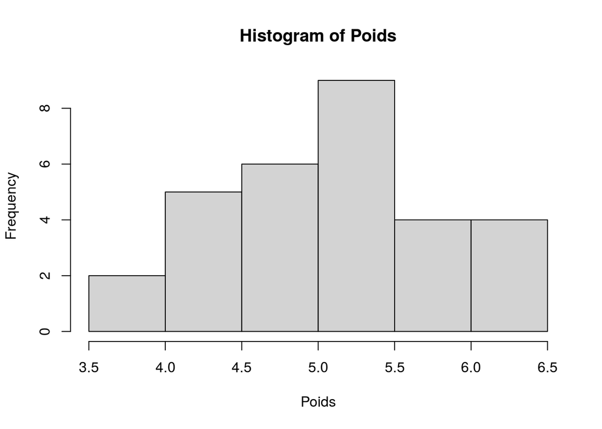

```r
#qqnorm() : function plots your sample against a normal distribution.
#qqline : line that allows you to ocularly assess whether you see a clear deviation from normality.

 #x <- rnorm(100)
 #x <- rgamma(100, 1)
 #hist(x)
 #qqnorm( x, main='QQ- plot')
 #qqline( x)

 hist(Poids)
```

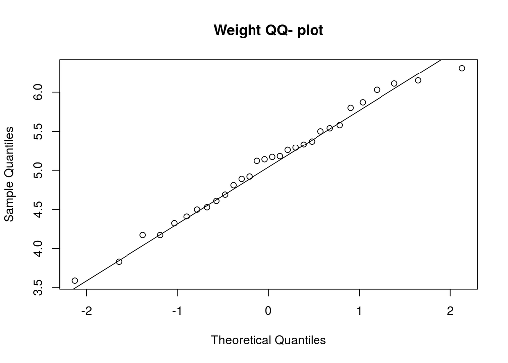

```r
 qqnorm( Poids, main='Weight QQ- plot')
 qqline( Poids )
```

#### Student’s t-test:

Used to test the null hypothesis that there is **no difference between the means** of **2 groups**.

- *one-sample t-test*: useful when comparing two populations X and Y. It tests if the mean of a sample from population X differs significantly from the given mean of population Y.
- *unpaired t-test*: two independent samples from one population. It tests if the population means estimated by two independent samples differ significantly.
- *paired t-test*: two dependent samples from one population. It tests if the population means estimated by two dependent samples differ significantly. (an example of dependent samples could be measurements made on the same subjects before and after a treatment)

#### Analysis of variance (ANOVA):

Used to test the null hypothesis that there is **no difference between the means** of **2 or more groups**.

In ANOVA, two variances are studied: – between-group variability - within-group variability Then, the two estimates of variances are compared using the F-test. F-statistics is computed as the ratio of the mean squares between the groups and the mean squares within groups.

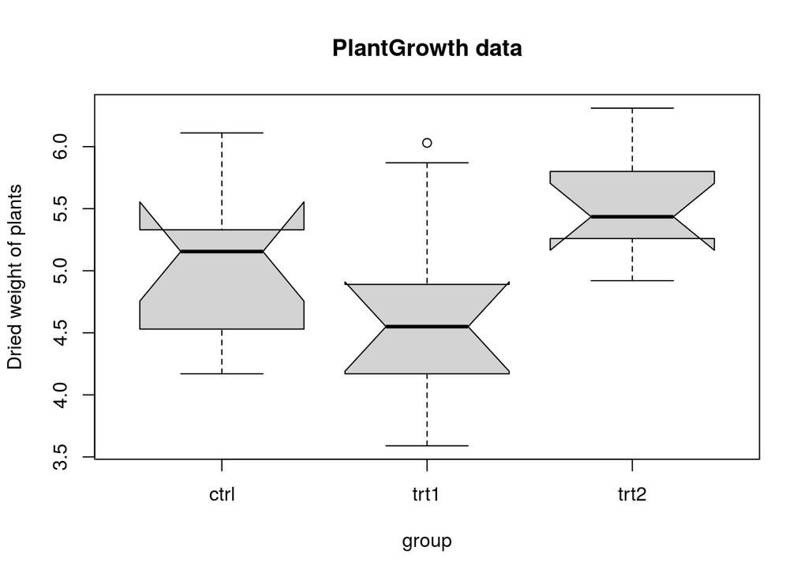

```r
## One factor ANOVA example from Dobson's book, cf. Table 7.4:
require(stats); require(graphics)
boxplot(weight ~ group, data = PlantGrowth, main = "PlantGrowth data",
        ylab = "Dried weight of plants", col = "lightgray",
        notch = TRUE, varwidth = TRUE)
```

ANOVA model could be used to help us answer the question whether any group weight means differ from another. ANOVA does not specify which groups differ.

```r
anova(lm(weight ~ group, data = PlantGrowth)) #ANOVA for Linear Model Fits
```

```
## Analysis of Variance Table
##
## Response: weight
##           Df  Sum Sq Mean Sq F value  Pr(>F)
## group      2  3.7663  1.8832  4.8461 0.01591 *
## Residuals 27 10.4921  0.3886
## ---
## Signif. codes:  0 '***' 0.001 '**' 0.01 '*' 0.05 '.' 0.1 ' ' 1
```

#### Pearson correlation coefficient

```r
install.packages("ggpubr")
library("ggpubr")
my_data <- mtcars
head(my_data, 6)
```

```
##                    mpg cyl disp  hp drat    wt  qsec vs am gear carb
## Mazda RX4         21.0   6  160 110 3.90 2.620 16.46  0  1    4    4
## Mazda RX4 Wag     21.0   6  160 110 3.90 2.875 17.02  0  1    4    4
## Datsun 710        22.8   4  108  93 3.85 2.320 18.61  1  1    4    1
## Hornet 4 Drive    21.4   6  258 110 3.08 3.215 19.44  1  0    3    1
## Hornet Sportabout 18.7   8  360 175 3.15 3.440 17.02  0  0    3    2
## Valiant           18.1   6  225 105 2.76 3.460 20.22  1  0    3    1
```

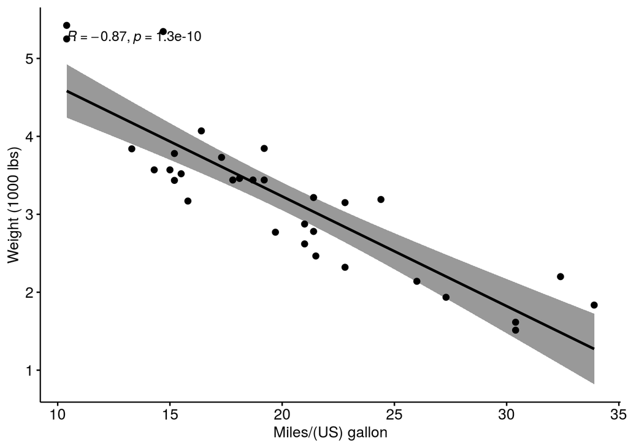

```r
ggscatter(my_data, x = "mpg", y = "wt",
          add = "reg.line", conf.int = TRUE,
          cor.coef = TRUE, cor.method = "pearson",
          xlab = "Miles/(US) gallon", ylab = "Weight (1000 lbs)")
```

```r
res <- cor.test(my_data$wt, my_data$mpg,
                    method = "pearson")
res
```

```
##
##  Pearson's product-moment correlation
##
## data:  my_data$wt and my_data$mpg
## t = -9.559, df = 30, p-value = 1.294e-10
## alternative hypothesis: true correlation is not equal to 0
## 95 percent confidence interval:
##  -0.9338264 -0.7440872
## sample estimates:
##        cor
## -0.8676594
```

```r
#    t is the t-test statistic value (t = -9.559),
 #   df is the degrees of freedom (df= 30),
 #   p-value is the significance level of the t-test (p-value = 1.29410^{-10}).
 #   conf.int is the confidence interval of the correlation coefficient at 95% (conf.int = [-0.9338, -0.7441]);
#    sample estimates is the correlation coefficient (Cor.coeff = -0.87).
```

### Non-PARAMETRIC TESTS

In case the distribution of the sample is skewed or **unknown**, **Non-parametric tests** are used.

The two-sample Kolmogorov-Smirnov (KS) test is used to test whether **two random samples*** are drawn from the **same distribution**.

The null hypothesis is that both distributions are identical. The statistic of the KS test is a distance between the two empirical distributions (computed as the maximum absolute difference between their cumulative curves).

### Bootstraping techniques:

Useful to estimate the mean and the median for the population using statistics from the sample. Assuming that data is representative The Bootstrap population obsr. from the sample appear many times

1- build a bootstrap sample that is a random sample with replacement from and with the same size as the sample. 2- compute the bootstrap statistic (mean, median…) 3- Reapeat 1 and 2 to create the Bootstrap distribution

```r
#https://cran.r-project.org/web/packages/infer/infer.pdf
#https://moderndive.github.io/moderndive_labs/static/previous_versions/v0.5.0/9-confidence-intervals.html#the-infer-package-for-statistical-inference

#install.packages("infer")
library(infer)

bootstrap_distribution<-Mydata1 %>%
specify(response = weight)  %>%     #weight as variable of interest
generate(reps = 1000, type = "bootstrap") %>%   # generate bootstrap sample. reps: the number of resamples to generate.
calculate(stat = "mean")        # Calculate mean of each bootstrap sample

bootstrap_distribution
```

```
## # A tibble: 1,000 x 2
##    replicate  stat
##        <int> <dbl>
##  1         1  5.18
##  2         2  4.90
##  3         3  5.00
##  4         4  5.01
##  5         5  4.86
##  6         6  4.94
##  7         7  4.87
##  8         8  4.80
##  9         9  5.10
## 10        10  4.99
## # … with 990 more rows
```

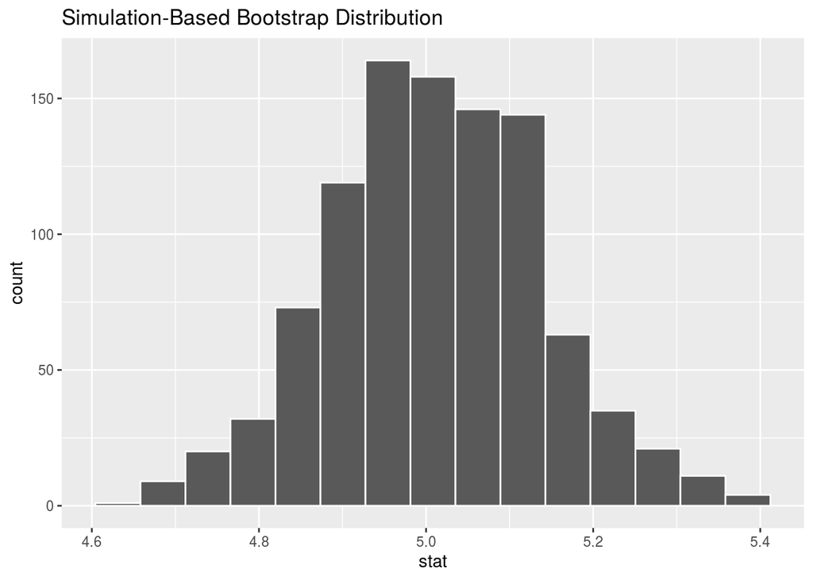

```r
bootstrap_distribution %>%
  visualize()
```

# References

Ali, Zulfiqar, and S Bala Bhaskar. 2016. “Basic Statistical Tools in Research and Data Analysis.” *Indian Journal of Anaesthesia* 60 (9): 662.